# Pandemia e alimentação: mudanças para melhor ou para pior?

Author

Gabriel Miranda

```r
library(readxl)
library(dplyr)
library(ggplot2)
library(tidyr)
library(knitr)
library(stringr)
library(gtsummary)
library(tidyverse)
library(ggstats)
library(ggridges)
library(tidymodels)
library(tidyclust)
#library(MASS)

dados0 <- read_excel("C:\\Users\\Usuario\\Desktop\\DataProjects\\quarto_archives\\DadosNutri.xlsx")

theme_gtsummary_language("pt", big.mark = ".", decimal.mark = ",")

explicativas = c(
     'Genero'
    ,'Raca_cor'
    ,'Regiao'
    ,'Renda_familiar'
    ,'Escolaridade'
    ,'Trabalha'
    ,'Idade'
    ,'Peso'
    ,'Dificuldade_Financeira'
)
desfechos = c(
     'Alteracao_Pandemia'
    ,'Frutas'
    ,'Legumes_Verduras'
    ,'Bebidas_Alcoolicas'
    ,'Produtos_Industrializados'
    ,'Doces'
)
```

# Introdução

Em 2022, alunas do curso de pós-graduação em Nutrição da UFF coletam 2359 respostas em um questionário online com 29 perguntas relacionadas a características sociodemográficas, condições vivenciadas durante a pandemia de COVID-19, características antropométricas e mudanças nos hábitos alimentares.

O objetivo desse estudo é, a partir da base de dados coletada, responder a seguinte pergunta: As mudanças de hábito alimentares na pandemia foram para bons ou maus hábitos?

```r
dados0 = dados0 %>%
    select(all_of(explicativas), all_of(desfechos))

tbl_summary(
    data = dados0 %>%
      select(all_of(explicativas), "Alteracao_Pandemia"),
    by = "Alteracao_Pandemia",
    statistic = list(all_categorical() ~ "{n} ({p}%)",
                     all_continuous() ~ "{median} [{p25} - {p75}]"),
    label = list(
        Genero ~ "Gênero",
        Raca_cor ~ "Raça/Cor",
        Regiao ~ "Região",
        Renda_familiar ~ "Renda familiar",
        Escolaridade ~ "Escolaridade",
        Trabalha ~ "Trabalha",
        Idade ~ "Idade (anos)",
        Dificuldade_Financeira ~ "Dificuldade financeira"
    )
) %>%
    modify_spanning_header(all_stat_cols() ~ "**Alteração de hábitos alimentares na pandemia**") %>%
    modify_header(label ~ "**Variáveis**") %>%
    bold_labels() %>%
    modify_caption("Descritiva das variáveis explicativas na amostra") %>%
  add_p(
    test = list(all_categorical() ~ "chisq.test"),
    pvalue_fun = ~ style_pvalue(.x, digits = 3)
  )
```

Descritiva das variáveis explicativas na amostra

| **Variáveis** | **Alteração de hábitos alimentares na pandemia** **Não** N = 624<sup>1</sup> | **Alteração de hábitos alimentares na pandemia** **Sim** N = 1.735<sup>1</sup> | **Valor-p**<sup>2</sup> |  |
| --- | --- | --- | --- | --- |
| Gênero |  |  |  | <0,001 |
| Feminino | 406 (65%) | 1.369 (79%) |  |  |
| Masculino | 218 (35%) | 366 (21%) |  |  |
| Raça/Cor |  |  | 0,231 |  |
| Amarela | 10 (1,6%) | 19 (1,1%) |  |  |
| Branca | 396 (63%) | 1.089 (63%) |  |  |
| Indígena | 0 (0%) | 10 (0,6%) |  |  |
| Outro | 2 (0,3%) | 3 (0,2%) |  |  |
| Parda | 177 (28%) | 477 (27%) |  |  |
| Preta | 39 (6,3%) | 137 (7,9%) |  |  |
| Região |  |  | 0,082 |  |
| Centro-oeste | 71 (11%) | 153 (8,8%) |  |  |
| Nordeste | 67 (11%) | 237 (14%) |  |  |
| Norte | 104 (17%) | 248 (14%) |  |  |
| Sudeste | 255 (41%) | 727 (42%) |  |  |
| Sul | 127 (20%) | 370 (21%) |  |  |
| Renda familiar |  |  | 0,001 |  |
| até R$ 1254,00 | 55 (8,8%) | 235 (14%) |  |  |
| entre R$ 1.255 - R$ 8.640 | 354 (57%) | 1.000 (58%) |  |  |
| mais de R$ 8.640 | 215 (34%) | 500 (29%) |  |  |
| Escolaridade |  |  | <0,001 |  |
| Ensino Fundamental Completo | 9 (1,4%) | 33 (1,9%) |  |  |
| Ensino Médio Completo | 194 (31%) | 726 (42%) |  |  |
| Ensino Superior Completo | 123 (20%) | 291 (17%) |  |  |
| Pós-graduação | 298 (48%) | 685 (39%) |  |  |
| Trabalha |  |  | <0,001 |  |
| Não | 153 (25%) | 562 (32%) |  |  |
| Sim | 471 (75%) | 1.173 (68%) |  |  |
| Idade (anos) | 36 [26 - 47] | 28 [22 - 39] | <0,001 |  |
| Peso | 67 [58 - 80] | 67 [58 - 78] | 0,821 |  |
| Dificuldade financeira |  |  | <0,001 |  |
| Não | 563 (90%) | 1.360 (78%) |  |  |
| Sim | 61 (9,8%) | 375 (22%) |  |  |

<sup>1</sup> n (%); Mediana [Q1 - Q3]  
<sup>2</sup> Teste qui-quadrado de independência; Teste de soma de postos de Wilcoxon

Sobre a alteração de hábitos alimentares na pandemia:

Pessoas que alteraram hábitos alimentares tinham predominantemente renda média/ (R$ 1,2 mil a R$ 8,6 mil+), ensino médio completo, não trabalhavam e enfrentaram dificuldades financeiras se comparadas a quem não mudou seus hábitos alimentares.

Disclaimer: A maior parte da base é de mulheres brancas da região sul/sudeste. Essa amostragem não é representativa para o Brasil, então a interpretação deve levar essa limitação em consideração. Além disso, a proporção de pessoas com pós graduação é muito semelhante a proporção de pessoas com ensino médio completo.

### Filtrando somente que declarou alteração de hábito na pandemia e selecionando as variáveis

O objetivo do estudo é entender o perfil de quem mudou os hábitos alimentares durante a pandemia e verificar o sentido dessa mudança (bons ou maus hábito), então o universo da análise vai levar em consideração somente que responder “Alteracao_Pandemia = Sim”

```r
variaveis_estudo = c(desfechos, 'Genero', 'Renda_familiar','Escolaridade','Trabalha', 'Idade','Dificuldade_Financeira')

dados = dados0 %>%
  filter(Alteracao_Pandemia == "Sim") %>%
  select(all_of(variaveis_estudo))
```

## Perfil sociodemográfico

1735 das 2359 pessoas que responderam ao questionário declararam que alteraram hábitos alimentares durante a pandemia.

```r
table1 <- dados %>%
  select(
    Genero, Renda_familiar, Escolaridade, Trabalha, Idade, Dificuldade_Financeira
  ) %>%
  tbl_summary(
    statistic = list(
      all_categorical() ~ "{n} ({p}%)",
      all_continuous() ~ "{median} [{p25} - {p75}]"
    ),
    digits = list(
      all_continuous() ~ 2,
      all_categorical() ~ c(0, 2)
    ),
    label = list(
      Genero ~ "Gênero",
      Renda_familiar ~ "Renda Familiar",
      Escolaridade ~ "Escolaridade",
      Trabalha ~ "Trabalha",
      Dificuldade_Financeira ~ "Dificuldade Financeira"
    ),
    missing = "no"
  ) %>%
  bold_labels() %>%
  modify_caption("Descritiva das variáveis explicativas entre quem mudou de hábito alimentar durante a pandemia")

table1
```

Descritiva das variáveis explicativas entre quem mudou de hábito alimentar durante a pandemia

| **Características** | **N = 1.735**<sup>1</sup> |
| --- | --- |
| Gênero |  |
| Feminino | 1.369 (78,90%) |
| Masculino | 366 (21,10%) |
| Renda Familiar |  |
| até R$ 1254,00 | 235 (13,54%) |
| entre R$ 1.255 - R$ 8.640 | 1.000 (57,64%) |
| mais de R$ 8.640 | 500 (28,82%) |
| Escolaridade |  |
| Ensino Fundamental Completo | 33 (1,90%) |
| Ensino Médio Completo | 726 (41,84%) |
| Ensino Superior Completo | 291 (16,77%) |
| Pós-graduação | 685 (39,48%) |
| Trabalha |  |
| Não | 562 (32,39%) |
| Sim | 1.173 (67,61%) |
| Idade | 28,00 [22,00 - 39,00] |
| Dificuldade Financeira |  |
| Não | 1.360 (78,39%) |
| Sim | 375 (21,61%) |

<sup>1</sup> n (%); Mediana [Q1 - Q3]

De modo geral, pessoas com renda familiar entre R$ 1.255 - R$ 8.640, ensino médio completo ou pós graduação, que trabalhavam e não passaram por dificuldade financeira durante a pandemia compoe o perfil de quem responder ter mudado os hábitos alimentares nesse período.

## Mudanças alimentares

Dentre as opções disponíveis no questionário, foram selecionadas as seguintes para classificar boa ou má mudança de hábito alimentar:

- Frutas
- Legumes e Verduras
- Bebidas Alcoólicas
- Produtos Industrializados
- Doces

```r
p_aderencia <- function(data, variable, ...) {
  res <- chisq.test(table(data[[variable]]))
  tibble::tibble(p.value = style_pvalue(res$p.value, digits = 3))
}

table2 <- dados %>%
  select(
    Frutas, Legumes_Verduras, Bebidas_Alcoolicas,
    Produtos_Industrializados, Doces
  ) %>%
  tbl_summary(
    statistic = all_categorical() ~ "{n} ({p}%)",
    digits = all_categorical() ~ c(0, 2),
    label = list(
      Frutas ~ "Frutas",
      Legumes_Verduras ~ "Legumes e Verduras",
      Bebidas_Alcoolicas ~ "Bebidas Alcoólicas",
      Produtos_Industrializados ~ "Produtos Industrializados",
      Doces ~ "Doces"
    ),
    missing = "no"
  ) %>%
    add_stat(fns = everything() ~ p_aderencia) %>%
  modify_header(p.value ~ "**Valor-p**") %>%
  modify_caption("Proporção das categorias nas variáveis desfecho") %>%
  bold_labels()

table2
```

Proporção das categorias nas variáveis desfecho

| **Características** | **N = 1.735**<sup>1</sup> | **Valor-p** |
| --- | --- | --- |
| Frutas |  | <0,001 |
| Aumentou | 762 (43,92%) |  |
| Diminuiu | 421 (24,27%) |  |
| Não alterou | 534 (30,78%) |  |
| Não tenho o hábito | 18 (1,04%) |  |
| Legumes e Verduras |  | <0,001 |
| Aumentou | 789 (45,48%) |  |
| Diminuiu | 380 (21,90%) |  |
| Não alterou | 542 (31,24%) |  |
| Não tenho o hábito | 24 (1,38%) |  |
| Bebidas Alcoólicas |  | <0,001 |
| Aumentou | 508 (29,28%) |  |
| Diminuiu | 353 (20,35%) |  |
| Não alterou | 393 (22,65%) |  |
| Não tenho o hábito | 481 (27,72%) |  |
| Produtos Industrializados |  | <0,001 |
| Aumentou | 580 (33,43%) |  |
| Diminuiu | 365 (21,04%) |  |
| Não alterou | 465 (26,80%) |  |
| Não tenho o hábito | 325 (18,73%) |  |
| Doces |  | <0,001 |
| Aumentou | 929 (53,54%) |  |
| Diminuiu | 365 (21,04%) |  |
| Não alterou | 371 (21,38%) |  |
| Não tenho o hábito | 70 (4,03%) |  |

<sup>1</sup> n (%)

Os valores-p muito pequenos indicam que as proporções nas respostas são significativamente diferentes. Podemos observar um aumento no consumo de todos os alimentos selecionados, com destaque para Doces, onde mais de 50% relataram aumento no seu consumo.

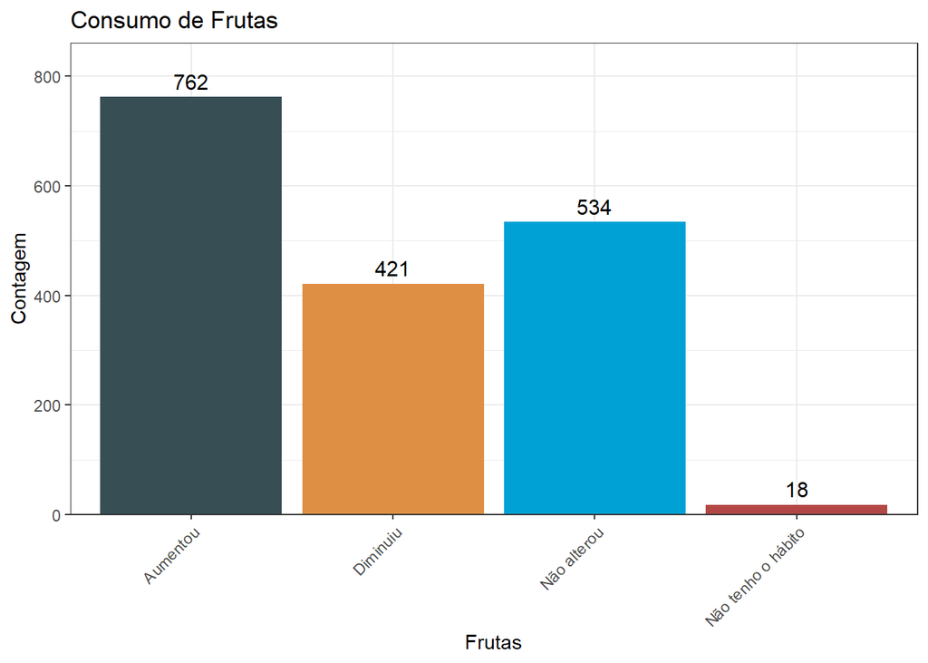

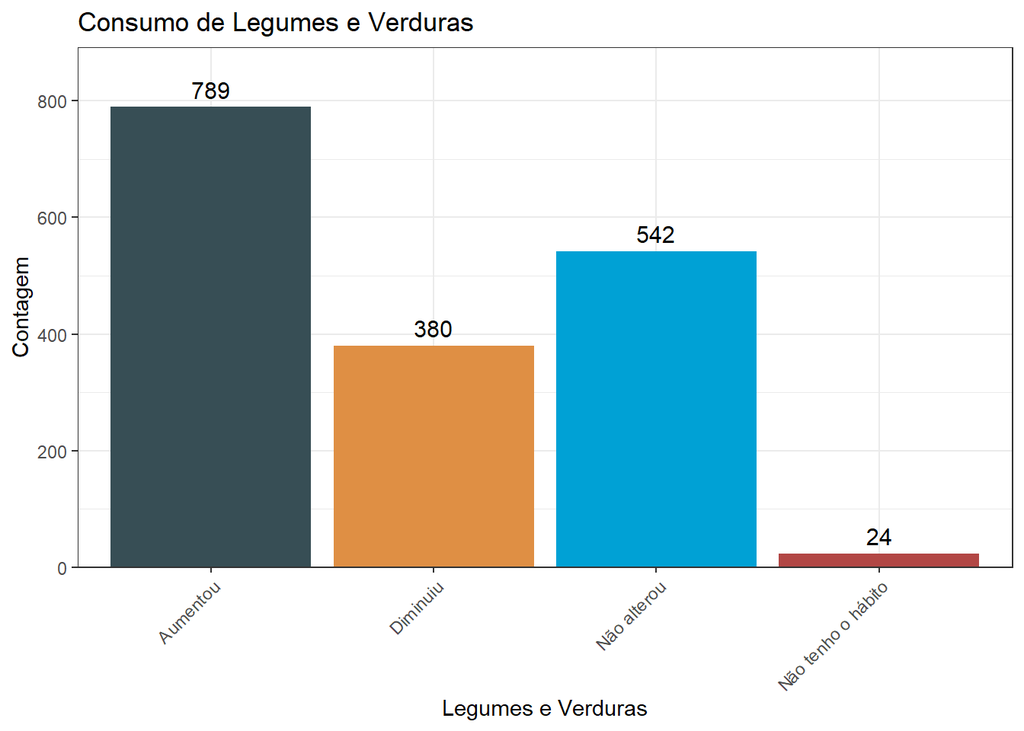

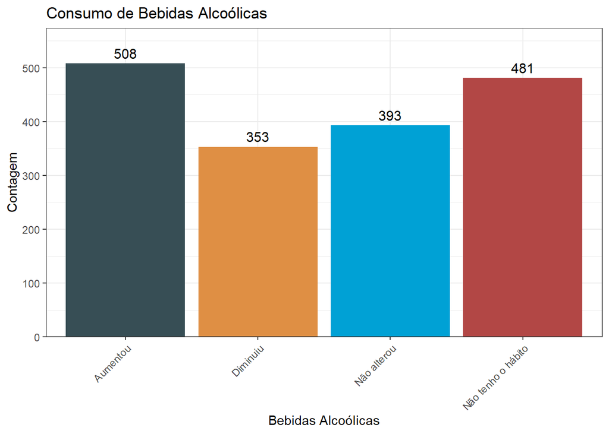

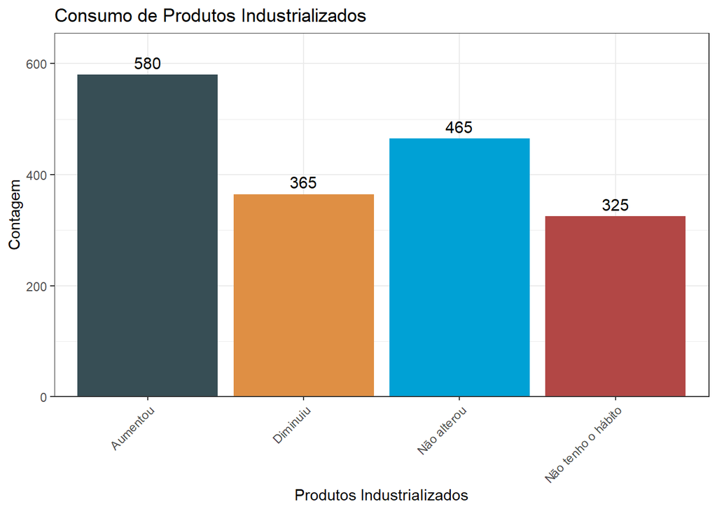

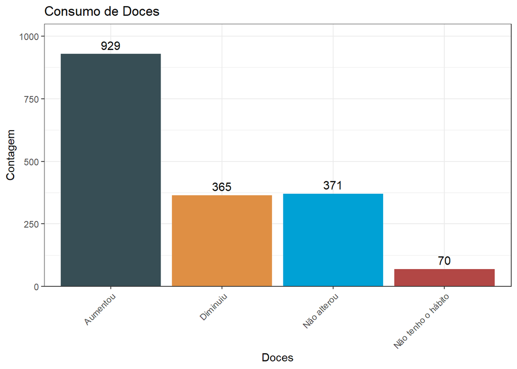

```r
jama_colors <- c('#374e55', '#df8f44', '#00a1d5', '#b24745')

labels_desfechos <- list(
  Frutas = "Frutas",
  Legumes_Verduras = "Legumes e Verduras",
  Bebidas_Alcoolicas = "Bebidas Alcoólicas",
  Produtos_Industrializados = "Produtos Industrializados",
  Consumo_agua = "Consumo de Água"
)

grafico_distribuicao <- function(df, col, labels_desfechos = list(), colors = jama_colors) {

  col_label <- if (col %in% names(labels_desfechos)) labels_desfechos[[col]] else col

  grafico <- ggplot(df, aes(x = .data[[col]], fill = .data[[col]])) +
    geom_bar() +
    stat_count(
      geom = "text",
      aes(label = after_stat(count)),
      vjust = -0.5,
      size = 4,
      color = "black"
    ) +
    scale_fill_manual(values = colors) +
    scale_y_continuous(expand = expansion(mult = c(0, 0.13))) +
    labs(
      title = paste("Consumo de", col_label),
      x = col_label,
      y = "Contagem"
    ) +
    theme_bw() +
    theme(
      axis.text.x = element_text(angle = 45, hjust = 1),
      legend.position = "none"
    )

  return(grafico)
}

for(i in 1:length( desfechos[2:length(desfechos)])){
  print(
    grafico_distribuicao(
    dados,
    desfechos[2:length(desfechos)][i],
    labels_desfechos)
  )
}
```

```r
explicativas <- c('Genero', 'Renda_familiar', 'Escolaridade', 'Trabalha', 'Dificuldade_Financeira')
desfechos    <- c('Frutas', 'Legumes_Verduras', 'Bebidas_Alcoolicas', 'Produtos_Industrializados', 'Doces')

resultados <- expand.grid(Explicativa = explicativas, Desfecho = desfechos, stringsAsFactors = FALSE) %>%
  rowwise() %>%
  mutate(
    p_valor = round(chisq.test(table(dados[[Explicativa]], dados[[Desfecho]]))$p.value, 5)
  ) %>%
  ungroup() %>%
  #arrange(Explicativa)
  arrange(desc(p_valor))

kable(resultados,
digits = 3,
caption = "Associação entre variável Explicativa com os alimentos selecionados")
```

Associação entre variável Explicativa com os alimentos selecionados

| Explicativa | Desfecho | p_valor |
| --- | --- | --- |
| Genero | Bebidas_Alcoolicas | 0.845 |
| Genero | Produtos_Industrializados | 0.626 |
| Genero | Frutas | 0.455 |
| Trabalha | Legumes_Verduras | 0.063 |
| Genero | Legumes_Verduras | 0.033 |
| Trabalha | Produtos_Industrializados | 0.018 |
| Escolaridade | Legumes_Verduras | 0.008 |
| Trabalha | Frutas | 0.008 |
| Renda_familiar | Doces | 0.003 |
| Escolaridade | Doces | 0.003 |
| Escolaridade | Frutas | 0.002 |
| Renda_familiar | Legumes_Verduras | 0.000 |
| Trabalha | Doces | 0.000 |
| Renda_familiar | Frutas | 0.000 |
| Dificuldade_Financeira | Frutas | 0.000 |
| Dificuldade_Financeira | Legumes_Verduras | 0.000 |
| Renda_familiar | Bebidas_Alcoolicas | 0.000 |
| Escolaridade | Bebidas_Alcoolicas | 0.000 |
| Trabalha | Bebidas_Alcoolicas | 0.000 |
| Dificuldade_Financeira | Bebidas_Alcoolicas | 0.000 |
| Renda_familiar | Produtos_Industrializados | 0.000 |
| Escolaridade | Produtos_Industrializados | 0.000 |
| Dificuldade_Financeira | Produtos_Industrializados | 0.000 |
| Genero | Doces | 0.000 |
| Dificuldade_Financeira | Doces | 0.000 |

# Gráficos 2 a 2

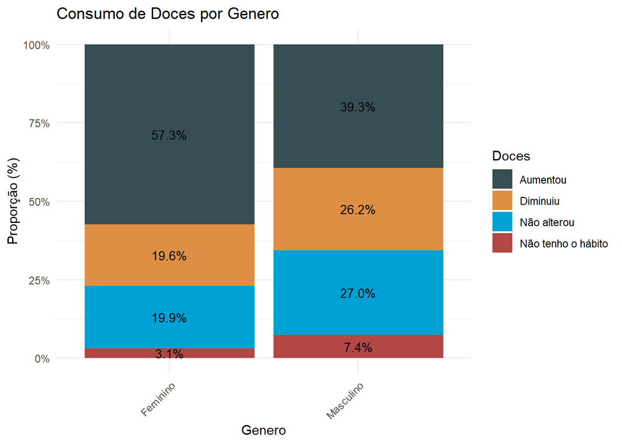

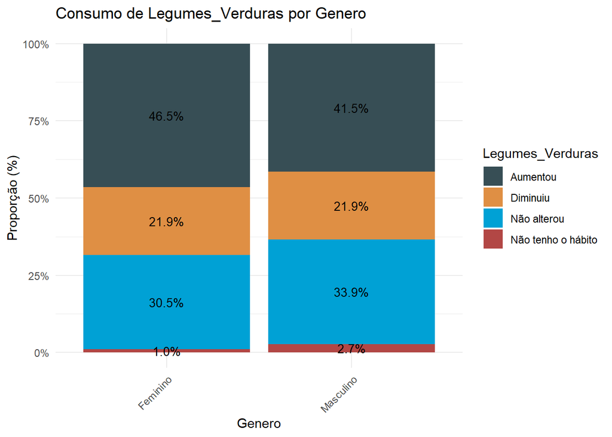

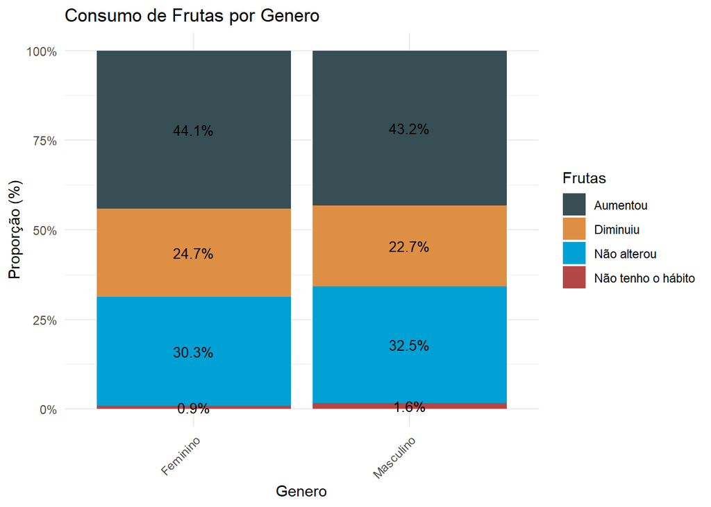

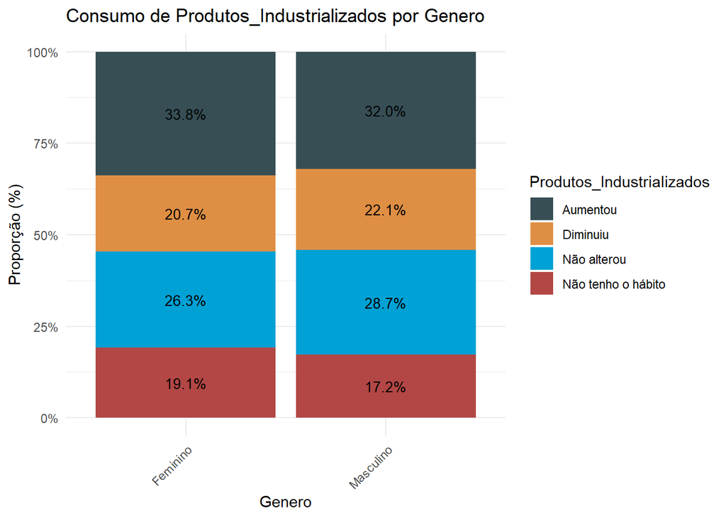

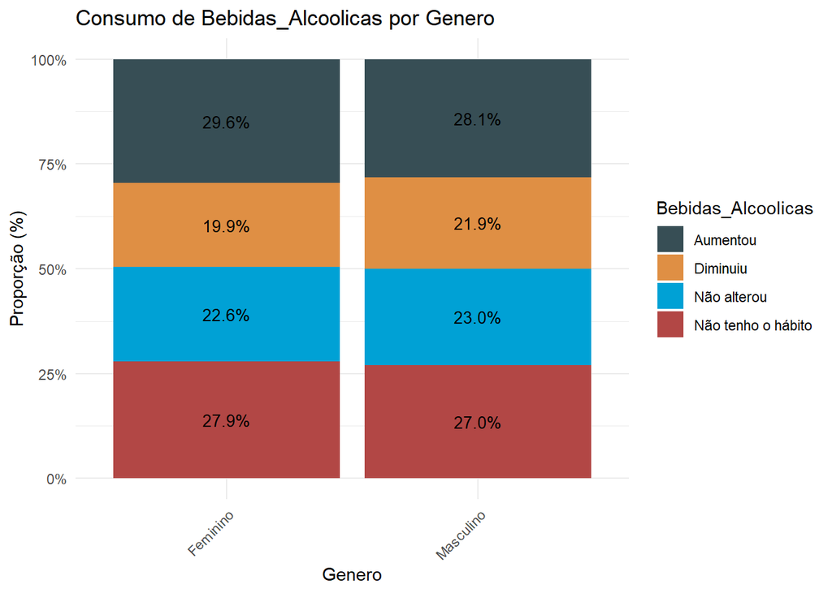

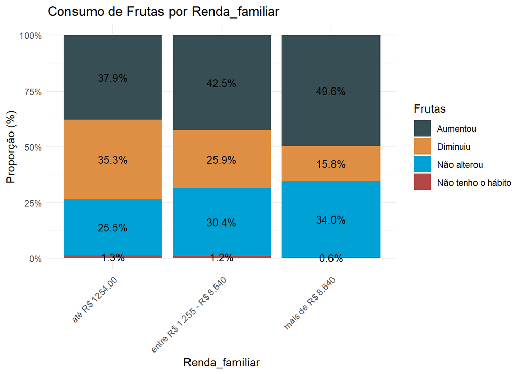

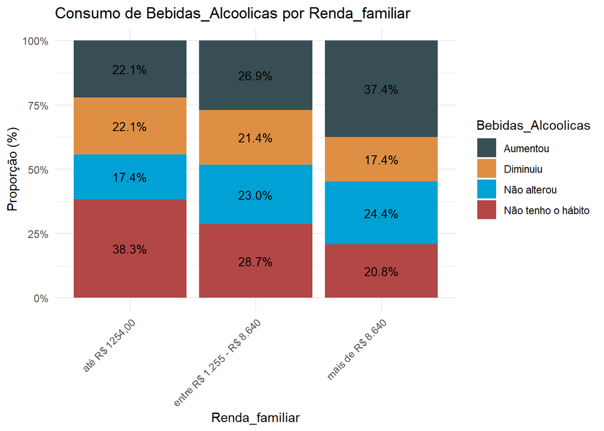

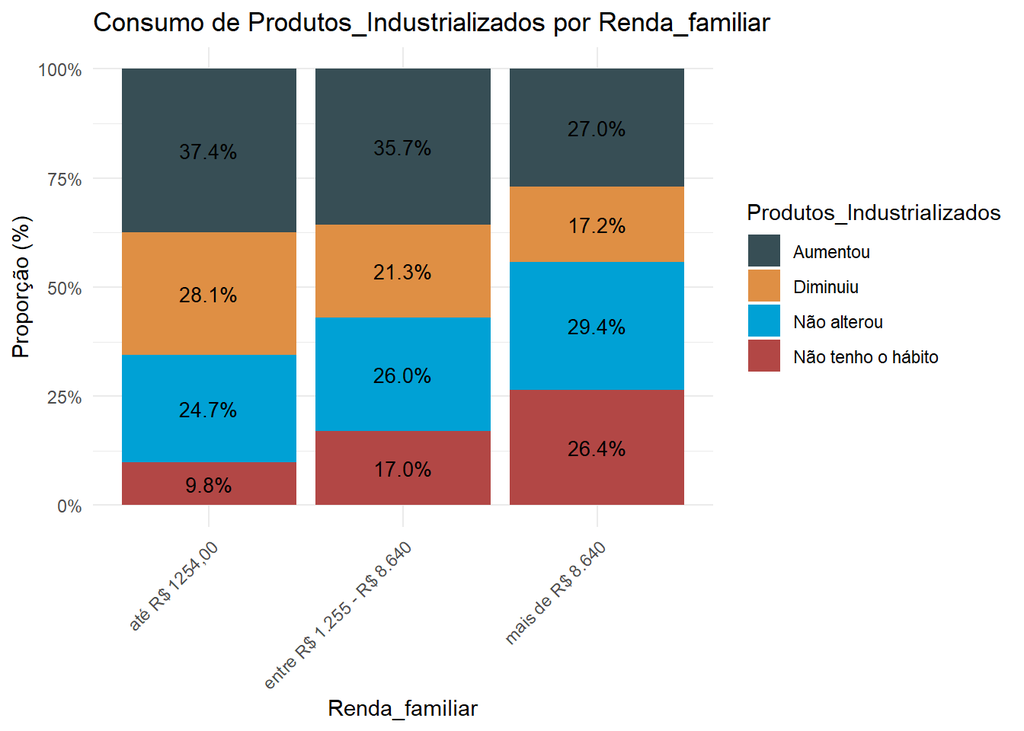

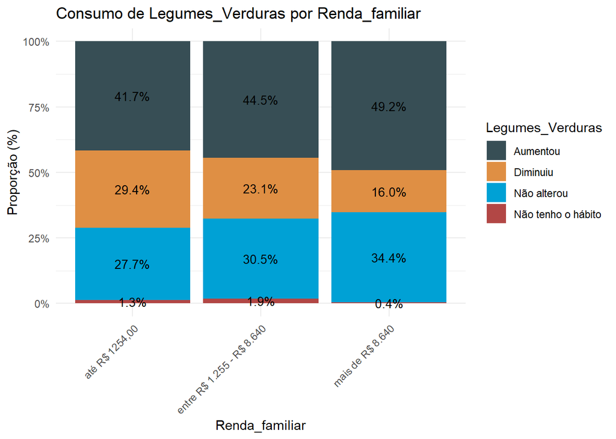

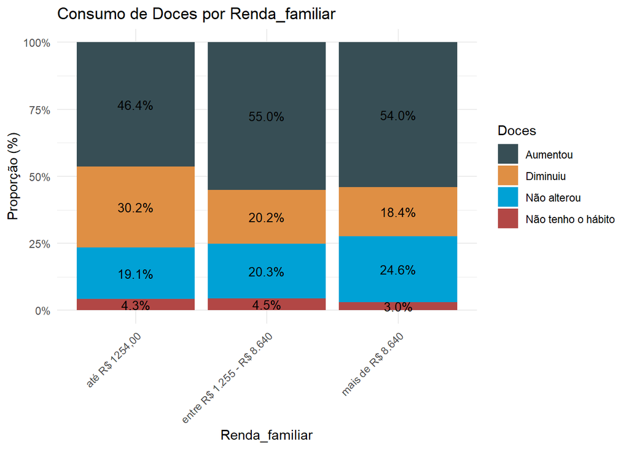

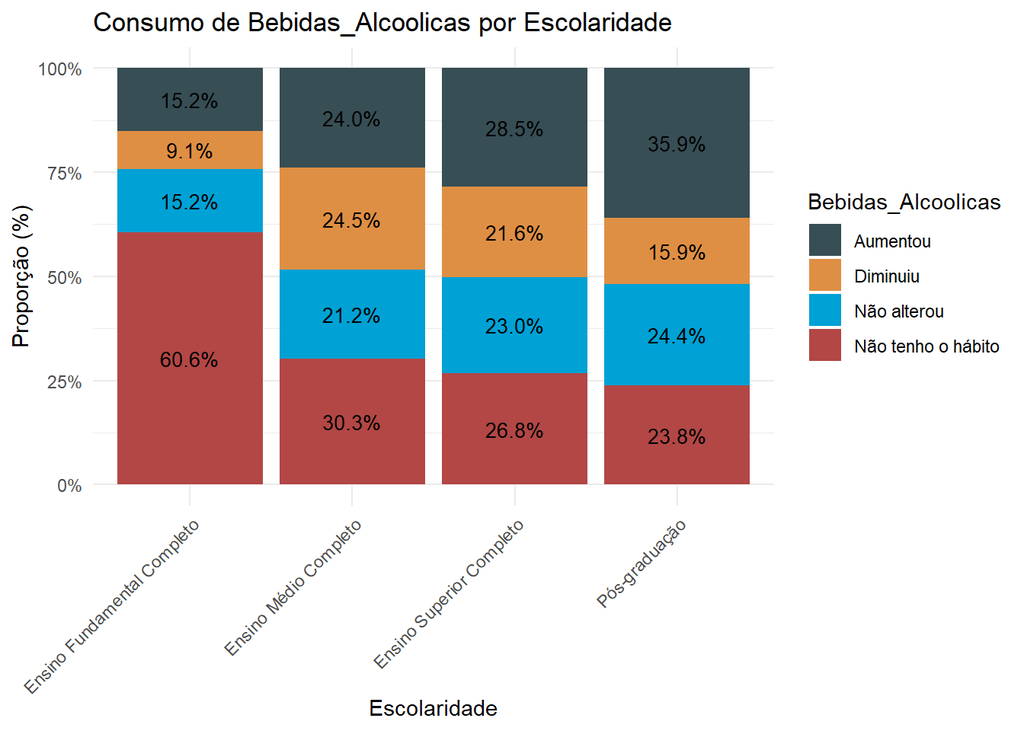

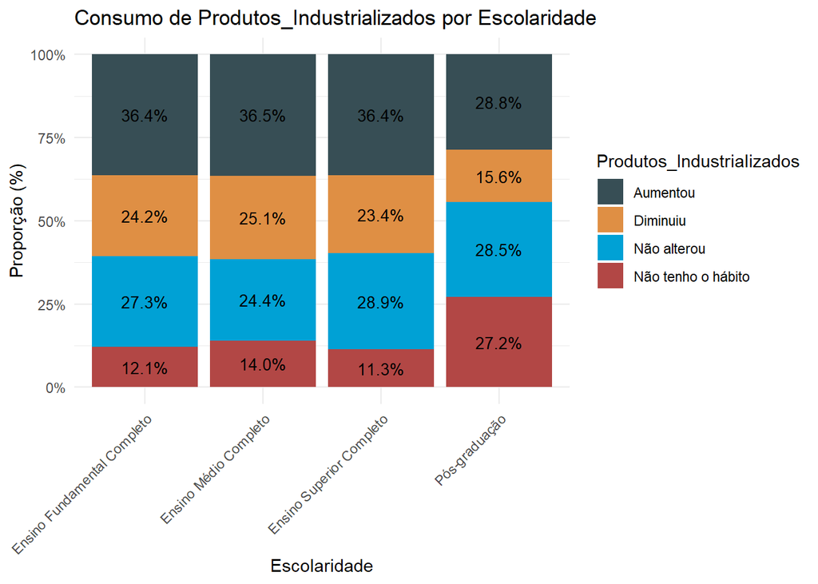

[13 more figures not shown]

```r
relacoes_significativas <- resultados %>%
  #filter(p_valor < 0.05) %>%
  mutate(Explicativa = factor(Explicativa, levels = explicativas)) %>%
  arrange(Explicativa, p_valor) # Ordena por Explicativa e depois pelo p-valor dentro de cada grupo

plot_bivariado <- function(exp, desf) {
  exp <- as.character(exp)

  ggplot(dados, aes(x = .data[[exp]], fill = .data[[desf]], by = .data[[exp]])) +
    geom_bar(position = "fill") +
    geom_text(stat = "prop", position = position_fill(0.5), size = 3.5) +
    scale_fill_manual(values = jama_colors, name = desf) +
    scale_y_continuous(labels = scales::percent) +
    labs(
      title = paste("Consumo de",desf, "por", exp),
      x = exp,
      y = "Proporção (%)"
    ) +
    theme_minimal() +
    theme(axis.text.x = element_text(angle = 45, hjust = 1))


}

graficos <- map2(relacoes_significativas$Explicativa,
                 relacoes_significativas$Desfecho,
                 plot_bivariado)

for(i in 1:length(graficos)){
  print(graficos[[i]])
}
```

## Qualitativa x Quantitativas

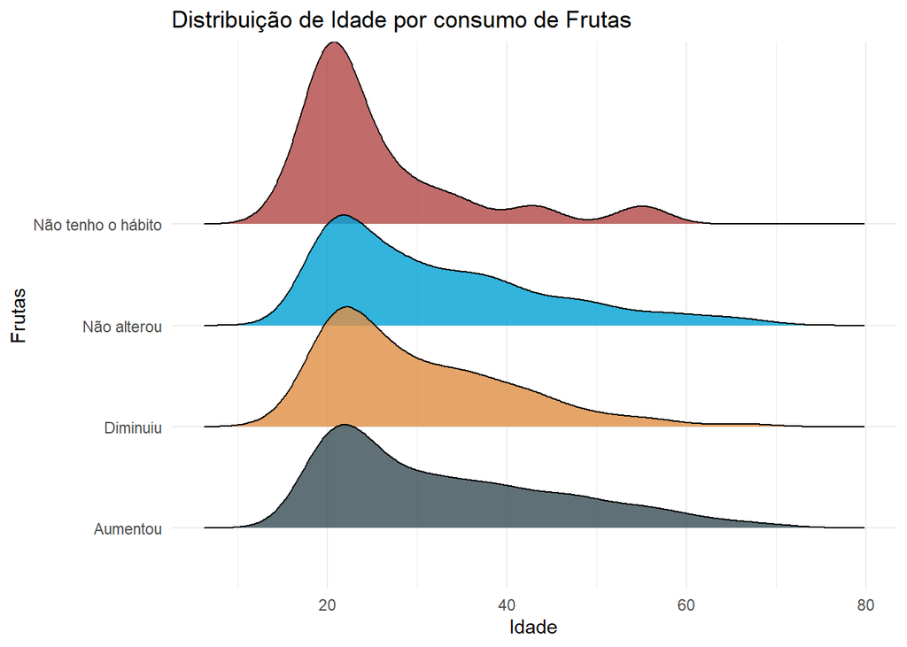

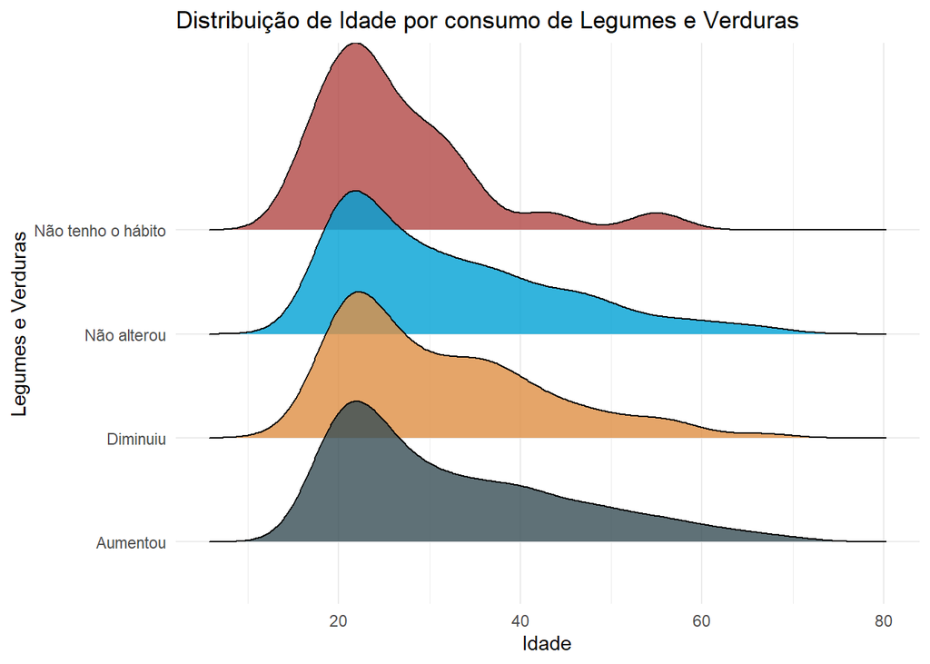

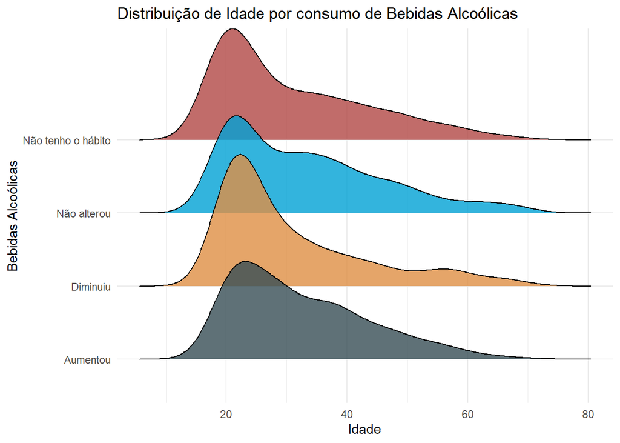

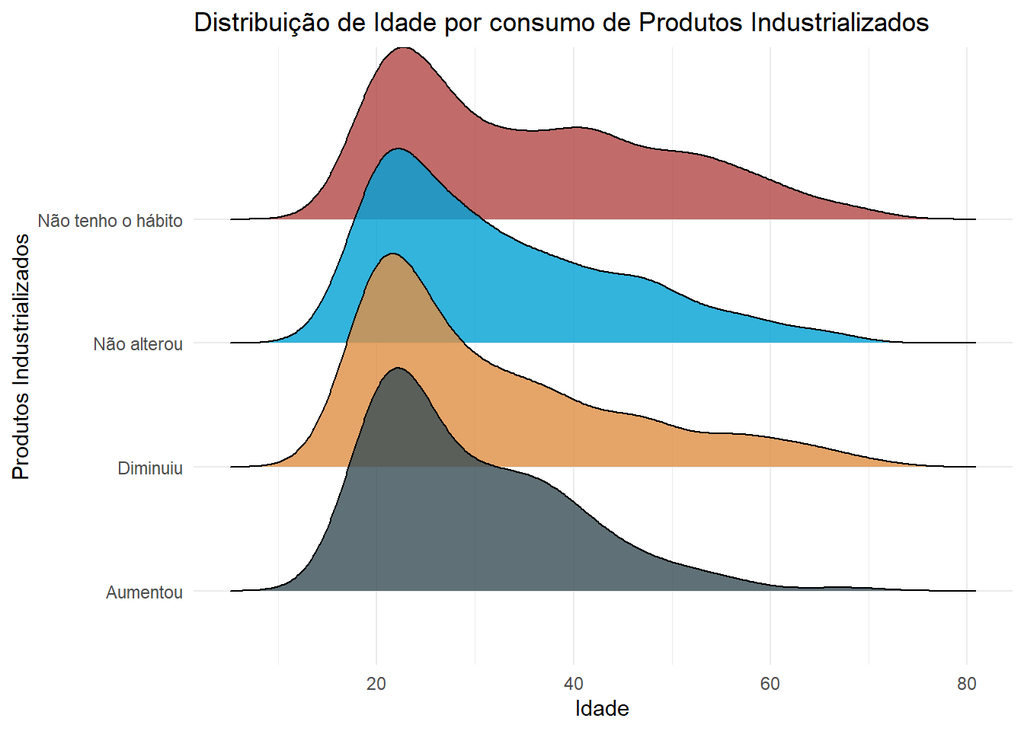

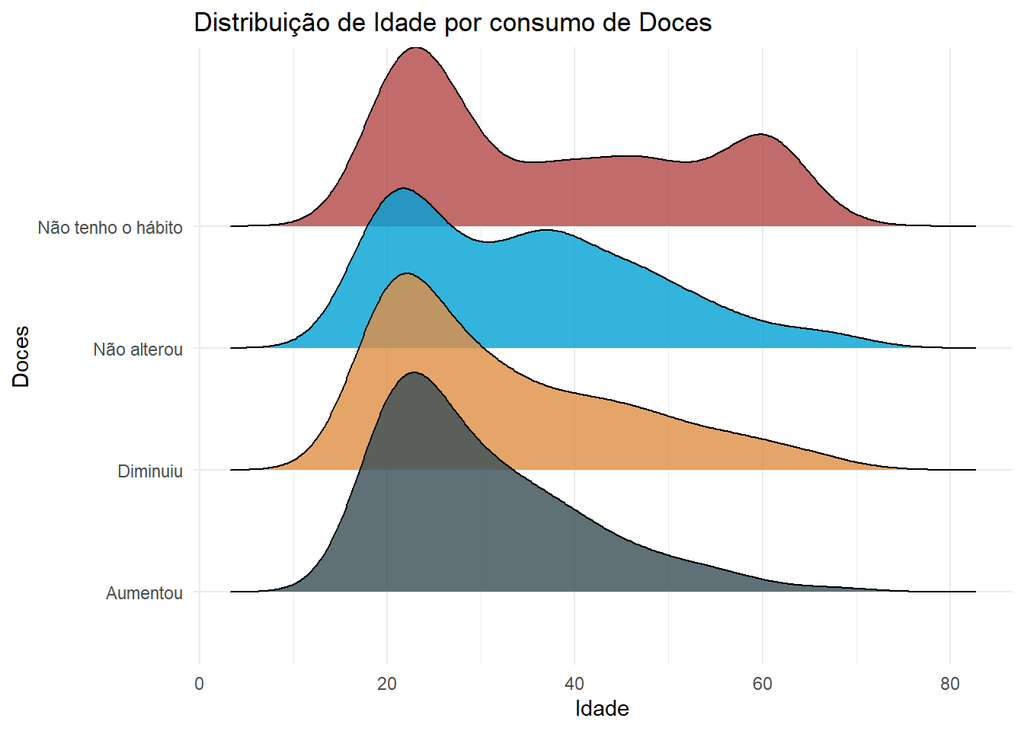

```r
variaveis = tibble(
  Quantitativa = rep("Idade", 5),
  Qualitativa = c('Frutas', 'Legumes_Verduras', 'Bebidas_Alcoolicas', 'Produtos_Industrializados', 'Doces')
)

labels_desfechos <- list(
  Frutas = "Frutas",
  Legumes_Verduras = "Legumes e Verduras",
  Bebidas_Alcoolicas = "Bebidas Alcoólicas",
  Produtos_Industrializados = "Produtos Industrializados",
  Consumo_agua = "Consumo de Água"
)

plot_bivariado <- function(exp, desf) {
  exp <- as.character(exp)
  desf <- as.character(desf)

  col_label <- if (desf %in% names(labels_desfechos)) labels_desfechos[[desf]] else desf

  ggplot(data = dados,
         mapping = aes(x = .data[[exp]], y = .data[[desf]], fill = .data[[desf]])) + # ADICIONADO: fill
    geom_density_ridges(alpha = 0.8, show.legend = FALSE) + # alpha melhora a visualização
    scale_fill_manual(values = jama_colors) +
    labs(
      title = paste("Distribuição de", exp, "por consumo de", col_label),
      x = exp,
      y = col_label
    ) +
    theme_minimal()
}

graficos <- map2(variaveis$Quantitativa,
                 variaveis$Qualitativa,
                 plot_bivariado)

for(i in 1:length(graficos)){
  print(graficos[[i]])
}
```

# Clusterização

Nessa seção foi aplicada a técnica de K-Means pra clusterização dos dados, onde foi possível identificar dois grupos:

- Mudanças para bons hábitos
- Mudanças para maus hábitos

```r
set.seed(2026)
dados_clust <- dados %>%
  select(Frutas, Legumes_Verduras, Bebidas_Alcoolicas, Produtos_Industrializados, Doces) %>%
  mutate(across(everything(), ~ case_when(
    . == "Não tenho o hábito" ~ 0,
    . == "Diminuiu"           ~ 1,
    . == "Não alterou"        ~ 2,
    . == "Aumentou"           ~ 3,
    TRUE                      ~ NA_real_
  )))

rec_kmeans <- recipe(~ ., data = dados_clust) %>%
  step_normalize(all_numeric_predictors())

spec_kmeans <- k_means(num_clusters = 2) %>%
  set_engine("stats")

wf_kmeans <- workflow() %>%
  add_recipe(rec_kmeans) %>%
  add_model(spec_kmeans)

fit_kmeans <- wf_kmeans %>% fit(data = dados_clust)

dados_com_clusters <- augment(fit_kmeans, new_data = dados_clust)

dadosc = dados %>%
  bind_cols(dados_com_clusters %>% select(.pred_cluster))
```

```r
tbl_summary(
    data = dadosc %>%
      select(all_of(c("Frutas", "Legumes_Verduras",
                      "Bebidas_Alcoolicas","Produtos_Industrializados",
                      "Doces" )), .pred_cluster)
    ,
    by = ".pred_cluster",
    statistic = list(all_categorical() ~ "{n} ({p}%)",
                     all_continuous() ~ "{mean} ({sd})")
) %>%
  modify_caption("Descritiva das variáveis desfecho para os Clusters")
```

Descritiva das variáveis desfecho para os Clusters

| **Características** | **Cluster_1** N = 938<sup>1</sup> | **Cluster_2** N = 797<sup>1</sup> |
| --- | --- | --- |
| Frutas |  |  |
| Aumentou | 702 (75%) | 60 (7,5%) |
| Diminuiu | 29 (3,1%) | 392 (49%) |
| Não alterou | 207 (22%) | 327 (41%) |
| Não tenho o hábito | 0 (0%) | 18 (2,3%) |
| Legumes_Verduras |  |  |
| Aumentou | 721 (77%) | 68 (8,5%) |
| Diminuiu | 15 (1,6%) | 365 (46%) |
| Não alterou | 202 (22%) | 340 (43%) |
| Não tenho o hábito | 0 (0%) | 24 (3,0%) |
| Bebidas_Alcoolicas |  |  |
| Aumentou | 247 (26%) | 261 (33%) |
| Diminuiu | 224 (24%) | 129 (16%) |
| Não alterou | 195 (21%) | 198 (25%) |
| Não tenho o hábito | 272 (29%) | 209 (26%) |
| Produtos_Industrializados |  |  |
| Aumentou | 126 (13%) | 454 (57%) |
| Diminuiu | 273 (29%) | 92 (12%) |
| Não alterou | 256 (27%) | 209 (26%) |
| Não tenho o hábito | 283 (30%) | 42 (5,3%) |
| Doces |  |  |
| Aumentou | 375 (40%) | 554 (70%) |
| Diminuiu | 270 (29%) | 95 (12%) |
| Não alterou | 238 (25%) | 133 (17%) |
| Não tenho o hábito | 55 (5,9%) | 15 (1,9%) |

<sup>1</sup> n (%)

```r
tbl_summary(
    data = dadosc %>%
      select(all_of(c('Genero', 'Renda_familiar','Escolaridade',
                      'Trabalha', 'Idade', 'Dificuldade_Financeira')), .pred_cluster)
    ,
    by = ".pred_cluster",
    statistic = list(all_categorical() ~ "{n} ({p}%)",
                     all_continuous() ~ "{median} [{p25} - {p75}]")
) %>%
  modify_caption("Descritiva das variáveis explicativas para os Clusters")
```

Descritiva das variáveis explicativas para os Clusters

| **Características** | **Cluster_1** N = 938<sup>1</sup> | **Cluster_2** N = 797<sup>1</sup> |
| --- | --- | --- |
| Genero |  |  |
| Feminino | 742 (79%) | 627 (79%) |
| Masculino | 196 (21%) | 170 (21%) |
| Renda_familiar |  |  |
| até R$ 1254,00 | 105 (11%) | 130 (16%) |
| entre R$ 1.255 - R$ 8.640 | 532 (57%) | 468 (59%) |
| mais de R$ 8.640 | 301 (32%) | 199 (25%) |
| Escolaridade |  |  |
| Ensino Fundamental Completo | 12 (1,3%) | 21 (2,6%) |
| Ensino Médio Completo | 369 (39%) | 357 (45%) |
| Ensino Superior Completo | 143 (15%) | 148 (19%) |
| Pós-graduação | 414 (44%) | 271 (34%) |
| Trabalha |  |  |
| Não | 289 (31%) | 273 (34%) |
| Sim | 649 (69%) | 524 (66%) |
| Idade | 29 [22 - 42] | 27 [21 - 37] |
| Dificuldade_Financeira |  |  |
| Não | 771 (82%) | 589 (74%) |
| Sim | 167 (18%) | 208 (26%) |

<sup>1</sup> n (%); Mediana [Q1 - Q3]

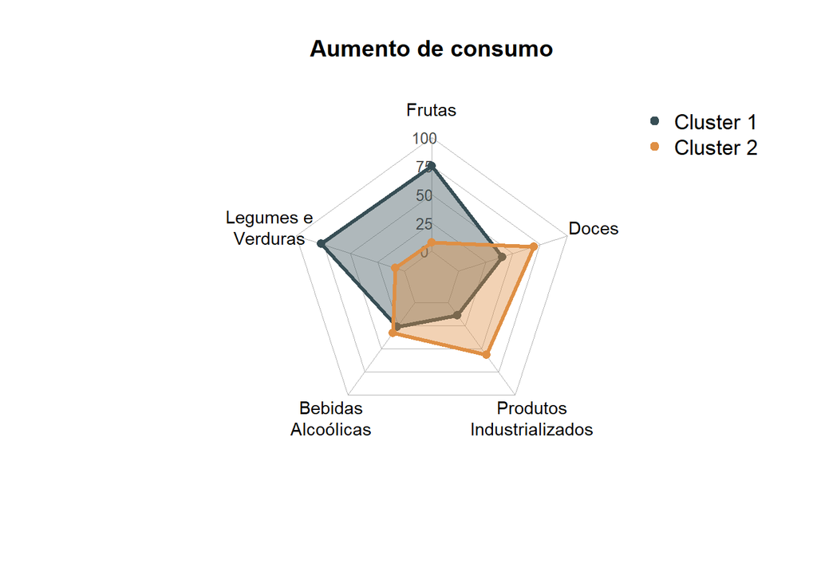

```r
library(fmsb)
variaveis_radar <- c(
  "Frutas",
  "Legumes_Verduras",
  "Bebidas_Alcoolicas",
  "Produtos_Industrializados",
  "Doces"
)

Radar_df <- dadosc %>%
  mutate(.pred_cluster = if_else(.pred_cluster == "Cluster_1", "Cluster 1", "Cluster 2")) %>%
  group_by(.pred_cluster) %>%
  summarise(
    across(
      all_of(variaveis_radar),
      ~ mean(.x == "Aumentou", na.rm = TRUE) * 100
    )
  ) %>%
  ungroup()

Radar <- Radar_df %>%
  select(-.pred_cluster) %>%
  as.data.frame()

Radar <- rbind(
  rep(100, length(variaveis_radar)),
  rep(0, length(variaveis_radar)),
  Radar
)

n_clusters <- nrow(Radar_df)

colors_border <- c(
  jama_colors
)[seq_len(n_clusters)]

colors_in <- paste0(
  colors_border,
  "66"
)

radarchart(
  Radar,
  axistype = 1,
  pcol = colors_border,
  pfcol = colors_in,
  plwd = 3,
  plty = 1,
  cglcol = "grey70",
  cglty = 1,
  cglwd = 0.8,
  axislabcol = "grey30",
  caxislabels = seq(0, 100, 25),
  calcex = 0.8,
  vlcex = 0.9,
  vlabels = c(
    "Frutas",
    "Legumes e\nVerduras",
    "Bebidas\nAlcoólicas",
    "Produtos\nIndustrializados",
    "Doces"
  ),
  title = "Aumento de consumo"
)

legend(
  "topright",
  legend = Radar_df$.pred_cluster,
  bty = "n",
  pch = 20,
  col = colors_border,
  text.col = "black",
  cex = 1.1,
  pt.cex = 1.5
)
```

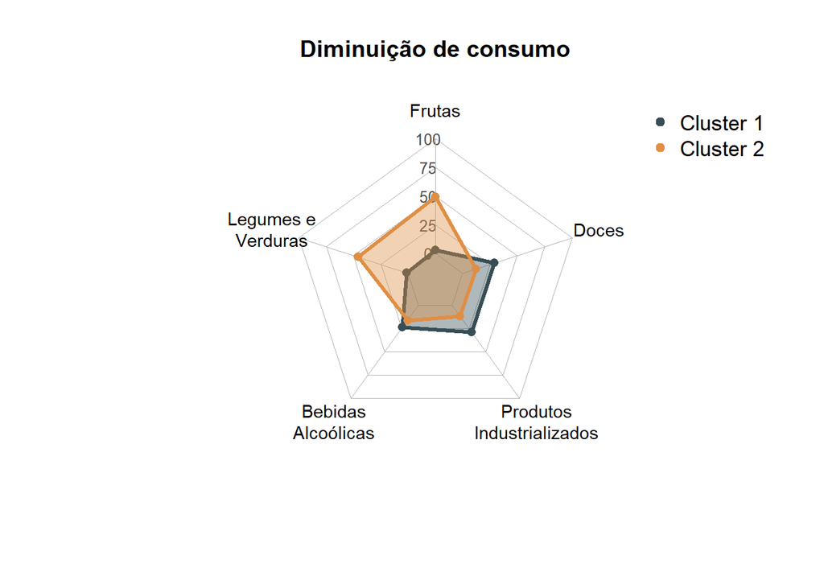

```r
Radar_df <- dadosc %>%
  mutate(.pred_cluster = if_else(.pred_cluster == "Cluster_1", "Cluster 1", "Cluster 2")) %>%
  group_by(.pred_cluster) %>%
  summarise(
    across(
      all_of(variaveis_radar),
      ~ mean(.x == "Diminuiu", na.rm = TRUE) * 100
    )
  ) %>%
  ungroup()

Radar <- Radar_df %>%
  select(-.pred_cluster) %>%
  as.data.frame()

Radar <- rbind(
  rep(100, length(variaveis_radar)),
  rep(0, length(variaveis_radar)),
  Radar
)

n_clusters <- nrow(Radar_df)

colors_border <- c(
  jama_colors
)[seq_len(n_clusters)]

colors_in <- paste0(
  colors_border,
  "66"
)

radarchart(
  Radar,
  axistype = 1,
  pcol = colors_border,
  pfcol = colors_in,
  plwd = 3,
  plty = 1,
  cglcol = "grey70",
  cglty = 1,
  cglwd = 0.8,
  axislabcol = "grey30",
  caxislabels = seq(0, 100, 25),
  calcex = 0.8,
  vlcex = 0.9,
  vlabels = c(
    "Frutas",
    "Legumes e\nVerduras",
    "Bebidas\nAlcoólicas",
    "Produtos\nIndustrializados",
    "Doces"
  ),
  title = "Diminuição de consumo"
)

legend(
  "topright",
  legend = Radar_df$.pred_cluster,
  bty = "n",
  pch = 20,
  col = colors_border,
  text.col = "black",
  cex = 1.1,
  pt.cex = 1.5
)
```

Ou seja, podemos separar os respondentes dos questionários em 2 grupos:

- Os que aumentaram o consumo de alimentos saudáveis (cluster 1):
  - Aumentou: Frutas, Legumes/Verduras
  - Diminuiu/Não tenho o hábito: Bebidas Alcoolicas, Produtos Industrializados
  - Maior proporção na faixa de alta renda;
  - Maior proporção de pós graduados;
  - Menor proporção de não-trabalho;
  - Menor proporção de dificuldade financeira;
  - Idades mais dispersa (p25 = 22 e p75 = 42)
- Os que aumentaram o consumo de alimentos não-saudáveis (cluster 2):
  - Aumentou: Bebidas Alcoolicas, Produtos Industrializados, Doces
  - Diminuiu: Frutas, Legumes/Verduras
  - Menor proporção na faixa de alta renda;
  - Maior proporção de fundamental e médio completo;
  - Maior proporção de dificuldade financeira;
  - Idades mais concentradas (p25 = 21 e p75 = 37)

# Principais Achados

### Quem mudou de hábito na pandemia?

Ou seja, podemos observar o seguinte recorte em quem reportou mudança de hábito: menor renda, menor escolaridade, não exercia atividade laboral e relatou dificuldade financeira.

### Principais características de quem mudou seus hábitos alimentares na pandemia

Pessoas com renda familiar entre R$ 1.255 - R$ 8.640, ensino médio completo ou pós graduação, que trabalhavam e não passaram por dificuldade financeira durante a pandemia compoe o perfil de quem responder ter mudado os hábitos alimentares nesse período.

### Como se deu o consumo dos grupos alimentares

Pudemos observar um aumento no consumo de todos os alimentos selecionados, com destaque para Doces, onde mais de 50% relataram aumento no seu consumo.

O consumo de bebidas alcoolicas, frutas, legumes/verduras aumentou conforme aumentava a escolaridade do respondente. Além disso, a maior proporção de ‘Não tenho hábito’ no consumo de de produtos industrializados foi nos respondentes pós graduados.

O consumo de bebidas alcoolicas, produtos industrializados e doces foi menor dentre as pessoas que trabalham.

O consumo de todos os alimentos selecionados apresentou maior proporção de diminuiu para quem passou por dificuldades financeiras se comparado ao Não.

O consumo de todos os alimentos selecionados, exceto produtos industrializados, aumentou dentre as pessoas de maior renda familiar (mais de R$ 8640,00).

Já a distribuição das idades foi bem similar para cada categoria de consumo alimentar listada.

O complemento dessas análises foi feito via clusterização.

### Clusterização para avaliar a direção da mudança de hábito

- Mudanças para bons hábitos
- Mudanças para maus hábitos

**Mudanças para bons hábitos**

Aumentou o consumo de frutas e legumes/verduras. Enquanto diminuiu ou não alterou o consumo de de bebidas alcoolicas, produtos industrializados.

Esse grupo é caracterizado por uma maior proporção de alta renda familiar e pós graduados, e menor proporção de não-trabalho e de dificuldade financeira. Além disso, uma população mais velha, com percentil 75 em 42 anos.

**Mudanças para maus hábitos**

Aumentou o consumo de bebidas alcoolicas, produtos industrializados e doces. Enquanto diminuiu o consumo de frutas e legumes/verduras

Esse grupo é caracterizado por uma menor proporção de alta renda familiar, maior proporção de dificuldade financeira na pandemia e maior proporção de ensino fundamental e médio completo. Além disso, uma população mais nova, com percentil 75 em 37 anos.

Pudemos observar que, pelos dados, foi possível identificar um grupo que mudou para bons hábitos e outro que mudou para maus hábitos. E essas diferenças podem estar relacionadas a um recorte social, uma vez que ficam claras as diferenças entre os dois grupos.

No começo da análise pudemos ver que quem não relatou mudanda de hábito durante a pandemia tem um perfil demográfico similar ao de quem relatou mudança para bons hábitos.

# Apendice

## Criação de um “escore alimentar”

Aqui foi testada a criação de um escore para se verificar se poderia ser observada via odds-ratio a influencia das variáveis explicativas numa escala de melhora/piora alimentar.

Para os alimentos saudáveis (Frutas, Legumes_Verduras), se aumentou o consumo soma 1 ponto e se diminuiu o consumo subtrai um ponto, e vice-versa para os alimentos não-saudáveis.

Se a soma ficou menor do que zero, é classificado como piorou. Se maior do que zero, melhorou. E se igual a zero, manteve os hábitos.

Abaixo a quantidade de pessoas em cada categoria segundo o escore.

```r
calcular_escore_alimentar <- function(dados,
                                      cols_saudaveis = c("Frutas", "Legumes_Verduras"),
                                      cols_nao_saudaveis = c("Bebidas_Alcoolicas", "Produtos_Industrializados", "Doces"),
                                      rotulo_aumentou = "Aumentou",
                                      rotulo_diminuiu = "Diminuiu",
                                      rotulos_sem_mudanca = c("Não alterou", "Não tenho o hábito")) {

  dados_proc <- dados

  pontuar_saudavel <- function(x) {
    ifelse(x == rotulo_aumentou, 1,
    ifelse(x == rotulo_diminuiu, -1,
    ifelse(x %in% rotulos_sem_mudanca, 0, NA)))
  }

  pontuar_nao_saudavel <- function(x) {
    ifelse(x == rotulo_aumentou, -1,
    ifelse(x == rotulo_diminuiu, 1,
    ifelse(x %in% rotulos_sem_mudanca, 0, NA)))
  }

  matriz_saudavel <- sapply(dados_proc[, cols_saudaveis, drop = FALSE], pontuar_saudavel)
  matriz_nao_saudavel <- sapply(dados_proc[, cols_nao_saudaveis, drop = FALSE], pontuar_nao_saudavel)

  dados_proc$Escore_Continuo <- rowSums(cbind(matriz_saudavel, matriz_nao_saudavel), na.rm = TRUE)

  dados_proc$Escore_Categoria <- factor(
    ifelse(dados_proc$Escore_Continuo > 0, "Melhorou",
    ifelse(dados_proc$Escore_Continuo < 0, "Piorou", "Manteve")),
    levels = c("Piorou", "Manteve", "Melhorou"),
    ordered = TRUE
  )

  return(dados_proc)
}

dados <- calcular_escore_alimentar(dados)
kable(table(dados$Escore_Categoria),
      caption = "Contagem nos grupos do escore alimentar",
      col.names = c(" ", "Total"))
```

Contagem nos grupos do escore alimentar

|  | Total |
| --- | --- |
| Piorou | 766 |
| Manteve | 266 |
| Melhorou | 703 |

Na tabela abaixo podemos ver que todos os valores-p são altos e, consequentemente, os intervalos de confiança das odds-ratio contêm o 1.

```r
ajustar_regressao_multivariada <- function(dados,
                                           var_resposta = "Escore_Categoria",
                                           preditores = c("Genero", "Renda_familiar", "Escolaridade", "Trabalha", "Dificuldade_Financeira")) {

  if (!requireNamespace("MASS", quietly = TRUE)) install.packages("MASS")

  dados[[var_resposta]] <- factor(dados[[var_resposta]], levels = c("Piorou", "Manteve", "Melhorou"), ordered = TRUE)

  for (p in preditores) {
    if (is.character(dados[[p]])) {
      dados[[p]] <- as.factor(dados[[p]])
    }
  }

  formula_modelo <- as.formula(paste(var_resposta, "~", paste(preditores, collapse = " + ")))

  modelo <- MASS::polr(formula_modelo, data = dados, Hess = TRUE)

  sumario <- summary(modelo)
  n_coef <- length(coef(modelo))

  nomes_coef <- names(coef(modelo))

  t_values <- sumario$coefficients[nomes_coef, "t value"]
  p_valores <- 2 * (1 - pnorm(abs(t_values)))

  or <- exp(coef(modelo))
  ci <- exp(confint.default(modelo)[nomes_coef, , drop = FALSE])

  tabela_or <- data.frame(
    Variavel = nomes_coef,
    Odds_Ratio = round(or, 3),
    IC_95_Inf = round(ci[, 1], 3),
    IC_95_Sup = round(ci[, 2], 3),
    p_valor = round(p_valores, 4)
  )

  rownames(tabela_or) <- NULL

  return(list(
    modelo_fit = modelo,
    tabela_resultados = tabela_or
  ))
}

resultado_regressao <- ajustar_regressao_multivariada(dados)

kable(resultado_regressao$tabela_resultados,
      caption = "Odds - Ratio para o escore alimentar",
      col.names = c("Variáveis", "Odds Ratio", "IC 95% sup", "IC 95% inf", "valor p"))
```

Odds - Ratio para o escore alimentar

[output not shown]

A criação desse escore não foi uma boa estratégia para diferenciar essas características.